# Treasury Dynamics of Polkadot and Kusama

Jonas Gehrlein

05.07.2023

## Introduction & Overview

This document provides an overview of the Treasury dynamics of both Polkadot and Kusama, utilizing the BigQuery infrastructure and queries developed and maintained by the exceptional Parity Data Team. The purpose of this document is to offer readers a deeper understanding of the mechanics of Treasury, factors that determine the **inflow** and **outflow**.

The funds kept in the Polkadot and Kusama Treasuries can be queried and verified just as any other account [here](https://polkadot.subscan.io/account/13UVJyLnbVp9RBZYFwFGyDvVd1y27Tt8tkntv6Q7JVPhFsTB) and [here](https://kusama.subscan.io/account/F3opxRbN5ZbjJNU511Kj2TLuzFcDq9BGduA9TgiECafpg29).

Tokens that are deposited into the Treasury, i.e., the **inflow**, is determined by the following mechanisms:

- **Transaction fees:** 80% of the transaction fees of every submitted extrinsic is diverted to the Treasury, while 20% is given to the block producers.
- **Staking inefficiencies:** the network knows an exogenously determined parameter called *ideal staking rate*. The APY for stakers (nominators & validators) decreases whenever the actual staking rate is not equal to that value. To keep inflation constant at 10%, the system does not print less tokens, rather some share of the overall reward for stakers is diverted to the Treasury (more information [here](https://research.web3.foundation/en/latest/polkadot/overview/2-token-economics.html)).
- **Slashes:** whenever validators and nominators are slashed, a share of the slashed tokens are diverted to Treasury. This is a rare and unpredictable event.
- **Transfers:** everyone can send funds to the Treasury directly. This is a rare event and mostly due to grantees reimbursing some of the amount they got allocated for various reasons.

The **outflow** is determined by the following mechanisms:

The remainder of the document illustrates various metrics for both Kusama and Polkadot. All values in plots are in their common denomination (KSM for Kusama and DOT for Polkadot). Note to properly check the scale of the y-axis to put values into perspective.

## In & Outflow

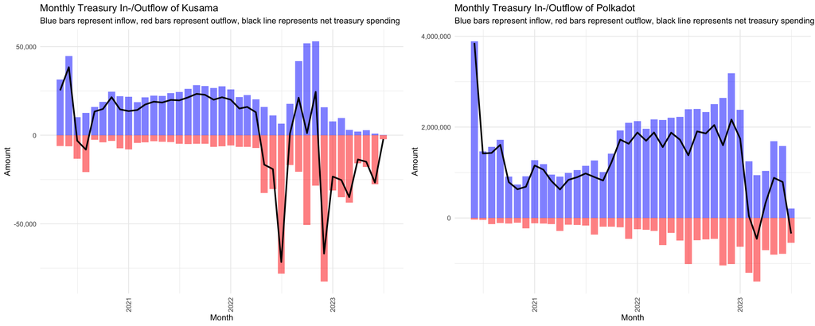

## Outflow (detailed)

The following graphs separate the outflow of the two Treasuries by the spending type.

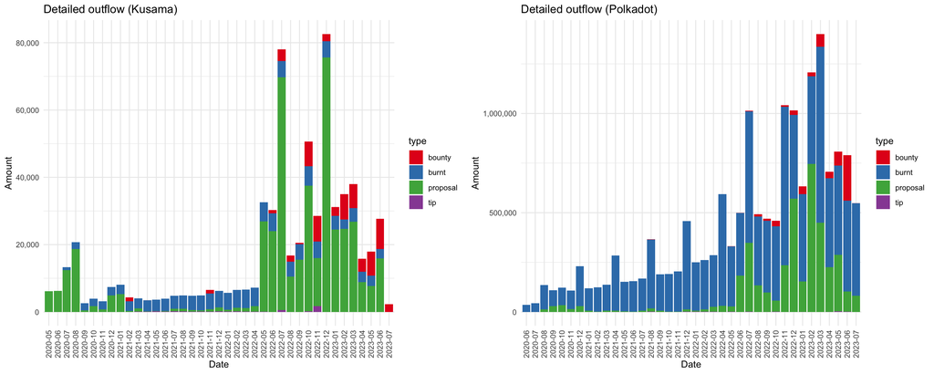

### Inflow (detailed)

The following graphs separate the inflow by the different possible types. For simplicity, slashes are omitted, but rarely happen anyway.

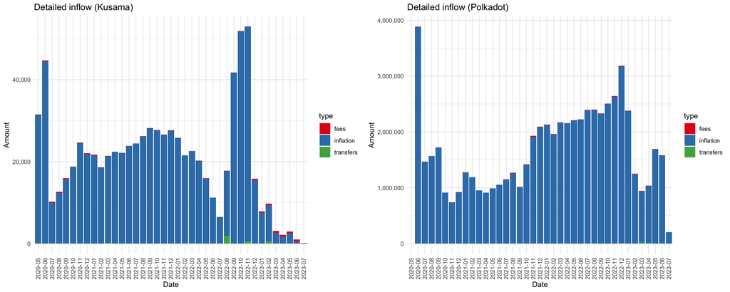

### Inflation Rewards to Treasury

The visualizations above clearly illustrate that the predominant portion of Treasury inflow originates from staking inefficiencies. The [token economics](https://research.web3.foundation/en/latest/polkadot/overview/2-token-economics.html) of these systems are purposefully designed to maintain a steady inflation rate (10%), while providing incentives for stakers to align the actual staking rate with a predetermined target (the ideal staking rate). Specifically, staking APY reaches its peak when the staking rate aligns with the ideal staking rate. Above or below this equilibrium, staking rewards decrease. To maintain a constant inflation rate, the surplus generated by keeping inflation steady is redirected to the Treasury.

It’s crucial to emphasize that in a system where the `staking_rate == ideal_staking_rate`, no inflow from inflation rewards would be directed to the Treasury.

Historically, at the inception of the network, the ideal staking rate was set at 75% due to the limited use cases of the token, which was either for liquidity or staking, in the absence of parachains. However, with the introduction of parachains, the ideal staking rate was programmed to scale with the number of parachains. This mechanism was first implemented on Kusama in the first half of 2021. Then, it took the auction counter as indicator. This metric was somewhat flawed at the point when leases first expired. A fix that counts the number of active parachains (excluding common good and system chains) was introduced in Runtime Upgrade 0.9.33. This upgrade was [executed in conjunction with 0.9.40](https://polkadot.polkassembly.io/referendum/96) on **January 14th, 2023**. This upgrade also established the mechanism on Polkadot. Consequently, the ideal staking rate experienced a sharp decline from 75% to approximately 54% on Polkadot. Given that, the inflow to the Treasury significantly diminished. This trend is evident in the data presented above, as the inflow decreased starting from February 2023, the first full month the mechanism was in operation.

In the graph below, we see the percentage of diversion to Treasury (relative to the total inflation).

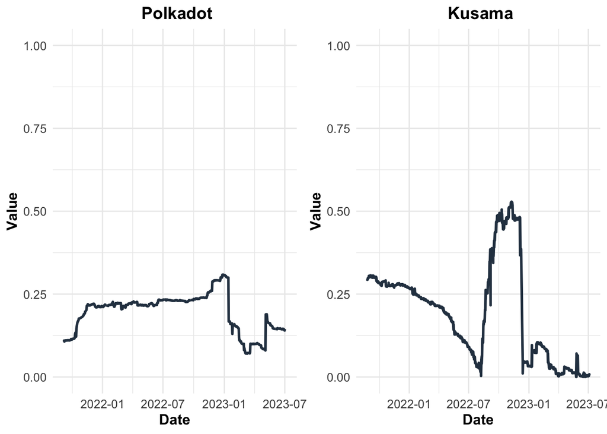

For Polkadot, the overall average share that went to the Treasury (from inflation rewards) is 19.6% since 2021-09-07 and 12.5% since 2023-01-15.